# Análise Estatística de Diabetes Tipo 2 em Mulheres da População Indígena Pima

Matheus Cândido e Fernando Simão

18 de março de 2026

## 1. Estatística Descritiva

Banco de dados: https://www.kaggle.com/datasets/uciml/pima-indians-diabetes-database

O quadro abaixo mostra os primeiros índices do banco de dados, dando uma melhor base de entendimento sobre sua utilizacao e variáveis:

Primeiras 10 linhas do dataset

| Pregnancies | Glucose | BloodPressure | SkinThickness | Insulin | BMI | DiabetesPedigreeFunction | Age | Outcome |
| --- | --- | --- | --- | --- | --- | --- | --- | --- |
| 6 | 148 | 72 | 35 | 169.5 | 33.6 | 0.627 | 50 | 1 |
| 1 | 85 | 66 | 29 | 102.5 | 26.6 | 0.351 | 31 | 0 |
| 8 | 183 | 64 | 32 | 169.5 | 23.3 | 0.672 | 32 | 1 |
| 1 | 89 | 66 | 23 | 94.0 | 28.1 | 0.167 | 21 | 0 |
| 0 | 137 | 40 | 35 | 168.0 | 43.1 | 2.288 | 33 | 1 |
| 5 | 116 | 74 | 27 | 102.5 | 25.6 | 0.201 | 30 | 0 |
| 3 | 78 | 50 | 32 | 88.0 | 31.0 | 0.248 | 26 | 1 |
| 10 | 115 | 70 | 27 | 102.5 | 35.3 | 0.134 | 29 | 0 |
| 2 | 197 | 70 | 45 | 543.0 | 30.5 | 0.158 | 53 | 1 |
| 8 | 125 | 96 | 32 | 169.5 | 34.3 | 0.232 | 54 | 1 |

## 2. Visualização de Dados

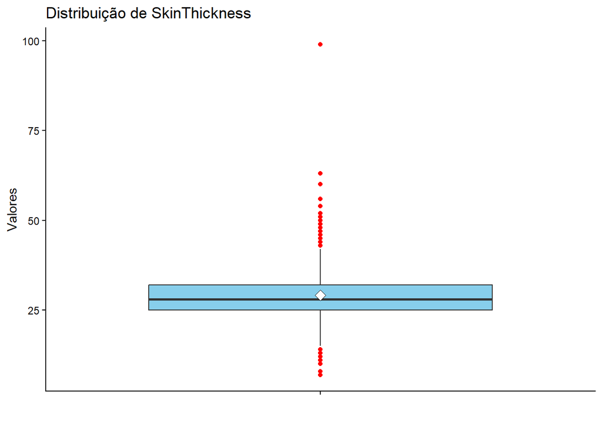

**Estabilidade:** A maior parte dos dados está concentrada em uma faixa estreita, com a mediana próxima de 30.

**Anomalias:** Note que existem pontos vermelhos tanto na parte superior (chegando a 100) quanto na parte inferior (próximo a 10).

**Ponto Crítico:** Um valor de 100mm para dobra cutânea é extremamente raro e pode indicar um erro de digitação ou medição no dataset original.

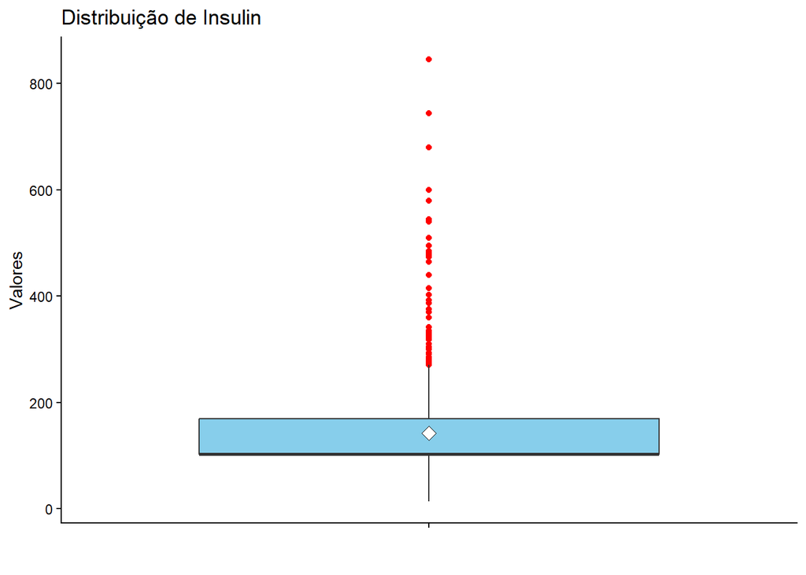

**Concentração:** A “caixa” azul está muito achatada na parte inferior, indicando que a grande maioria dos pacientes possui níveis de insulina baixos ou moderados (provavelmente entre 0 e 200).

**Outliers:** Há uma quantidade massiva de valores atípicos que se estendem até quase 900. Isso sugere uma cauda longa à direita (assimetria positiva), comum em dados biológicos onde alguns indivíduos apresentam resistência severa à insulina.

**Mediana:** Está posicionada bem abaixo no gráfico, reforçando que o valor “central” é baixo em comparação aos extremos detectados.

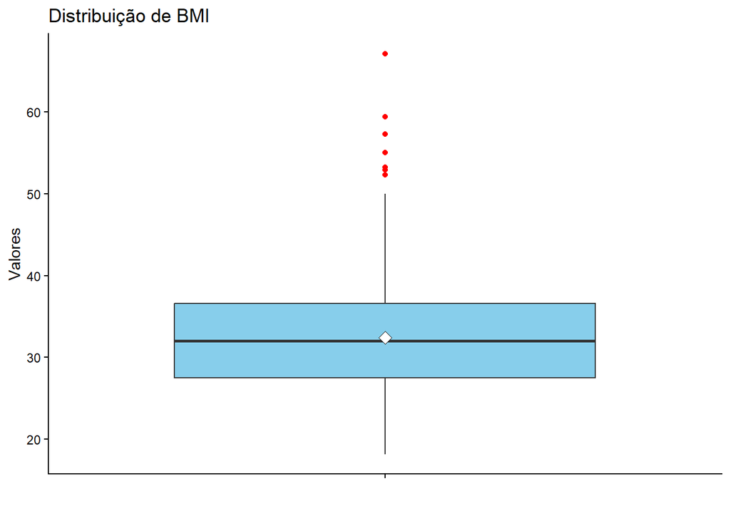

**Mediana:** A linha central da caixa está em torno de 32, o que já classifica a mediana desse grupo na faixa de Obesidade Grau I.

**Dispersão:** A caixa (Intervalo Interquartil) concentra-se aproximadamente entre 28 e 37.

**Outliers:** Existem pontos vermelhos que chedem a 60-70. Embora sejam valores extremos, são biologicamente possíveis em casos de obesidade mórbida, mas devem ser tratados com cuidado na modelagem preditiva.

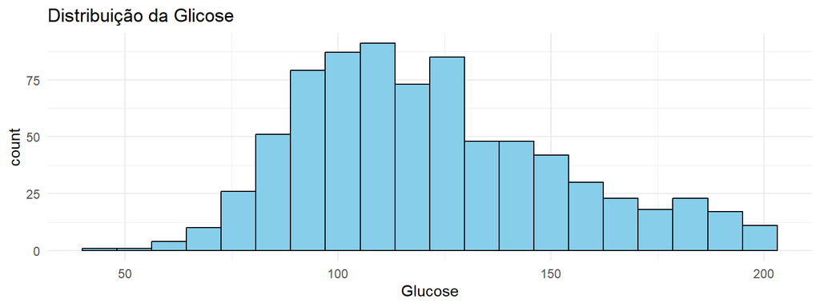

**Interpretação do Histograma:** O gráfico acima ilustra a distribuição de frequências dos níveis de Glicose na amostra. A análise visual permite avaliar a centralidade e a dispersão dos dados, bem como a aproximação da normalidade. Observa-se a concentração de pacientes em faixas glicêmicas específicas. A assimetria ou a presença de múltiplas modas neste tipo de distribuição frequentemente indica a coexistência de subpopulações distintas na amostra (neste caso, indivíduos saudáveis e indivíduos com tolerância à glicose prejudicada ou diabetes estabelecida).

## 3. Análise da correlação de Pearson

Para compreender a estrutura de dependência linear entre as covariáveis do modelo, calculamos os coeficientes de correlação de Pearson.O coeficiente resulta em um valor entre -1 e 1, onde valores extremos indicam forte associação linear (positiva ou negativa) e valores próximos a zero indicam ausência de relação linear

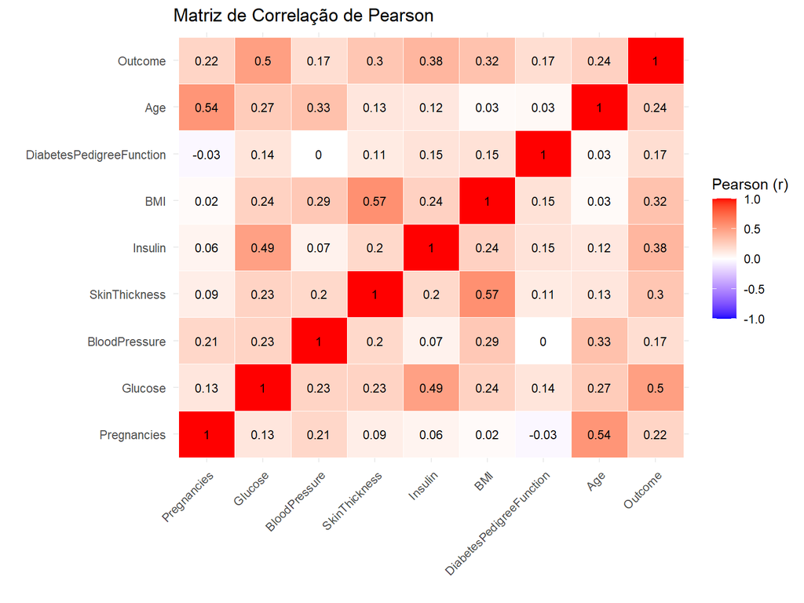

**Interpretação da Matriz de Correlação:** A representação visual em formato de mapa de calor facilita a rápida identificação de multicolinearidade entre as variáveis preditoras. As cores mais intensas (vermelho para correlações positivas e azul para correlações negativas) destacam os pares de variáveis que caminham em conjunto.

Observando os resultados, podemos notar relações biologicamente esperadas, tais como a correlação positiva moderada entre `Age` (Idade) e `Pregnancies` (Gestações), bem como entre `SkinThickness` (Espessura da Pele) e `BMI` (Índice de Massa Corporal). Identificar essas correlações é um passo fundamental antes da modelagem preditiva, pois variáveis altamente correlacionadas podem inserir redundância e inflar a variância dos estimadores em modelos de regressão múltipla.

**Observando a matriz de correlação mais de perto:**

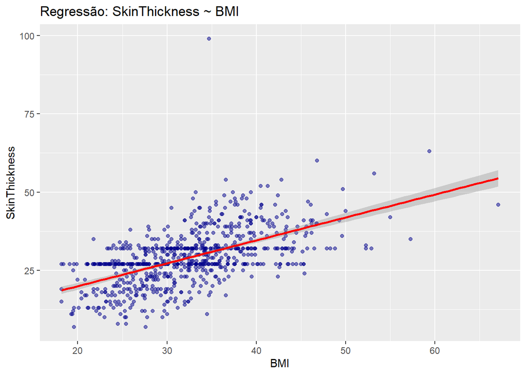

## 4. Testes de Hipóteses

Na inferência estatística, os testes estatísticos são regras de decisões, vinculadas a um fenômeno da população, que nos possibilitam avaliar, com o auxílio de uma amostra, se determinadas hipóteses podem ser rejeitadas, ou não. A seguir, aplicamos os testes paramétricos e não paramétricos exigidos para investigar as relações entre as variáveis clínicas e o diagnóstico de diabetes.

### 4.1 Teste Qui-Quadrado

O teste qui-quadrado de independência é usado para verificar se existe associação entre duas variáveis qualitativas (categóricas). A hipótese nula afirma independência entre as variáveis, enquanto a hipótese alternativa aponta para associação. Neste estudo, categorizamos as variáveis numéricas `Age` (Idade) e `Glucose` (Glicose) para avaliar suas associações categóricas com o diagnóstico (`Outcome`).
$$\chi^2 = \sum
\frac{(O_i - E_i)^2}{E_i}$$
Qui-quadrado é a soma das frequências observadas menos as frequências esperadas, ao quadrado, divididas pelas frequências esperadas.

```r
# ----------------------------------------
# Criar variáveis categóricas para teste
# ----------------------------------------

# Categorizar idade (jovem: <30, adulto: 30-50, idoso: >50)
dados$faixa_etaria <- cut(dados$Age,
                          breaks = c(0, 30, 50, 100),
                          labels = c("Jovem", "Adulto", "Idoso"))

# Categorizar glicose (normal: <140, alterada: >=140)
dados$glicose_cat <- ifelse(dados$Glucose < 140, "Normal", "Alterada")

# ----------------------------------------
# Execução dos Testes Qui-Quadrado
# ----------------------------------------

# Teste Qui-Quadrado: Faixa etária vs Outcome
tabela_idade <- table(dados$faixa_etaria, dados$Outcome)
print("Tabela de contingência - Idade vs Diabetes:")
```

```
## [1] "Tabela de contingência - Idade vs Diabetes:"
```

```r
print(tabela_idade)
```

```
##
##            0   1
##   Jovem  327  90
##   Adulto 130 140
##   Idoso   43  38
```

```r
qui_quadrado_idade <- chisq.test(tabela_idade)
print("Teste Qui-Quadrado - Idade vs Diabetes:")
```

```
## [1] "Teste Qui-Quadrado - Idade vs Diabetes:"
```

```r
print(qui_quadrado_idade)
```

```
##
##  Pearson's Chi-squared test
##
## data:  tabela_idade
## X-squared = 71.85, df = 2, p-value = 0.00000000000000025
```

**Como o p-value é extremamente pequeno, rejeitamos a hipótese nula (que diz que as variáveis eram independentes).**

O veredito: Existe uma associação estatisticamente significativa entre a faixa etária e o diagnóstico de diabetes nesse conjunto de dados. Em termos práticos, a idade é um fator de risco ou um preditor importante que devemos levar em conta.

```r
# Teste Qui-Quadrado: Glicose categorizada vs Outcome
tabela_glicose <- table(dados$glicose_cat, dados$Outcome)
print("Tabela de contingência - Glicose vs Diabetes:")
```

```
## [1] "Tabela de contingência - Glicose vs Diabetes:"
```

```r
print(tabela_glicose)
```

```
##
##              0   1
##   Alterada  62 137
##   Normal   438 131
```

```r
qui_quadrado_glicose <- chisq.test(tabela_glicose)
print("Teste Qui-Quadrado - Glicose vs Diabetes:")
```

```
## [1] "Teste Qui-Quadrado - Glicose vs Diabetes:"
```

```r
  print(qui_quadrado_glicose)
```

```
##
##  Pearson's Chi-squared test with Yates' continuity correction
##
## data:  tabela_glicose
## X-squared = 134.25, df = 1, p-value < 0.00000000000000022
```

**O teste indica uma associação altamente significativa** ($p < 0,001$) entre os níveis de glicose e o desfecho clínico, confirmando que a alteração na glicose ($\geq 140$ mg/dL) é um preditor determinante para a presença de diabetes nesta amostra.

### 4.2 Comparação de Variâncias (Teste F)

Realizamos o teste para comparação de duas variâncias a fim de avaliar a hipótese de homocedasticidade (variâncias iguais) entre os grupos diagnósticos para variáveis contínuas cruciais. A compreensão da dispersão ajuda a caracterizar a heterogeneidade clínica dos pacientes diabéticos em relação aos não diabéticos.
$$F
= \frac{s_1^2}{s_2^2}$$

Onde: * $s_1^2$: Variância da primeira amostra. * $s_2^2$: Variância da segunda amostra.

```r
# ----------------------------------------
# Comparar variância entre diabéticos e não diabéticos
# ----------------------------------------

# Glicose
teste_variancia_glucose <- var.test(Glucose ~ Outcome, data = dados)
print(teste_variancia_glucose)
```

```
##
##  F test to compare two variances
##
## data:  Glucose by Outcome
## F = 0.70181, num df = 499, denom df = 267, p-value = 0.0007725
## alternative hypothesis: true ratio of variances is not equal to 1
## 95 percent confidence interval:
##  0.5666371 0.8633286
## sample estimates:
## ratio of variances
##          0.7018063
```

**Conclusão:** O teste apresentou um p-valor significativo ($p = 0.00077$), indicando que as variâncias da glicose entre diabéticos e não diabéticos são estatisticamente diferentes.Implicação: Há maior dispersão nos níveis de glicose em um dos grupos. Em testes de comparação de médias (como o Teste t), deve-se obrigatoriamente usar o ajuste de Welch para variâncias desiguais.

```r
# BMI
teste_variancia_bmi <- var.test(BMI ~ Outcome, data = dados)
print(teste_variancia_bmi)
```

```
##
##  F test to compare two variances
##
## data:  BMI by Outcome
## F = 0.97325, num df = 499, denom df = 267, p-value = 0.7919
## alternative hypothesis: true ratio of variances is not equal to 1
## 95 percent confidence interval:
##  0.7857973 1.1972412
## sample estimates:
## ratio of variances
##          0.9732462
```

**Conclusão:** Com um p-valor de $0.7919$, não há evidências para rejeitar a hipótese de igualdade de variâncias.Implicação: O IMC apresenta uma dispersão homogênea entre os grupos (homocedasticidade). Isso valida o uso de modelos estatísticos paramétricos tradicionais que assumem variâncias constantes.

### 4.3 Comparação de Proporções

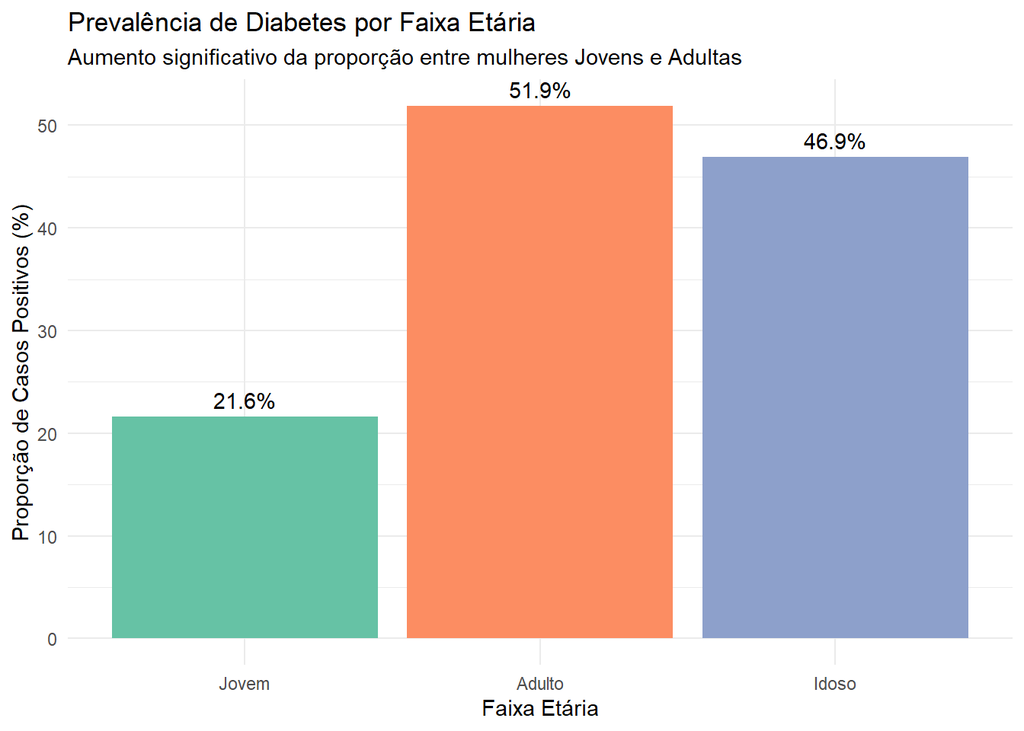

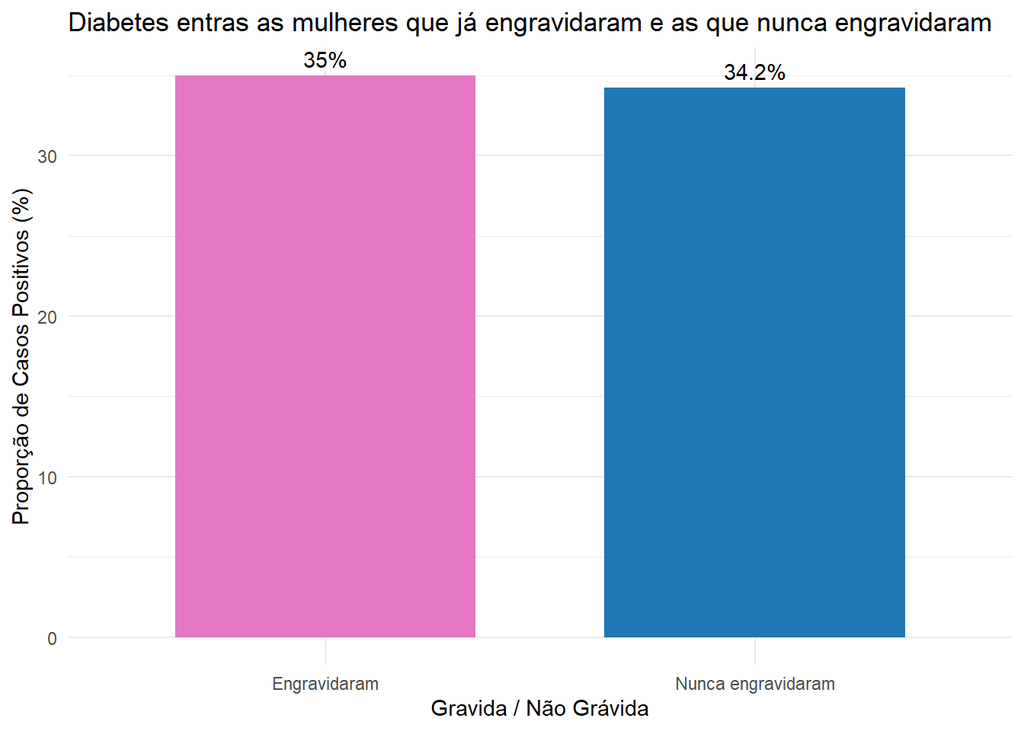

```
## [1] "Proporção de diabéticos por faixa etária (%):"
```

```
##
##              0     1
##   Jovem  78.42 21.58
##   Adulto 48.15 51.85
##   Idoso  53.09 46.91
```

## 5. Resumo dos Testes Estatísticos

**Resumo da Sessão: Testes de Hipóteses**

Nesta etapa, a análise deixou de ser meramente descritiva para se tornar inferencial, utilizando testes estatísticos para validar associações e diferenças observadas na amostra. Os principais achados foram:

**Associações Categóricas (Qui-Quadrado)**:O teste confirmou, com alto nível de significância ($p < 0,001$), que o diagnóstico de diabetes não é independente da Idade e dos níveis de Glicose. Observou-se que a transição da faixa “Jovem” para “Adulta” e o aumento da glicemia para níveis acima de $140$ mg/dL são fatores críticos que elevam a probabilidade de presença da doença.

**Homogeneidade de Variâncias (Teste F):**

Investigou-se a dispersão dos dados entre os grupos com e sem diabetes. Identificou-se variâncias desiguais na variável Glicose, o que exige cautela e ajustes em testes t de comparação de médias. Já para o BMI, as variâncias mostraram-se estáveis, permitindo comparações paramétricas diretas.

**Conclusão da Sessão:**

Os testes validaram que as variáveis selecionadas possuem forte fundamentação estatística para compor um modelo preditivo, garantindo que as relações observadas não são fruto do acaso, mas sim características intrínsecas dos dados biológicos analisados.

## 6. Análise de Regressão Linear

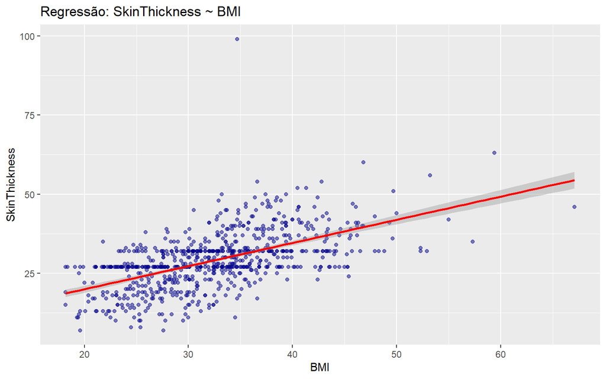

**Interpretação:** A reta de regressão (em vermelho) ilustra a tendência central da relação. A inclinação positiva da reta ($\hat{\beta}_1 > 0$) sugere que o aumento do BMI está linearmente associado à espessura da pele nos indivíduos na amostra analisada.

## 7 Conclusão

A análise estatística realizada sobre o conjunto de dados da população Pima forneceu evidências sólidas sobre os fatores de risco associados ao Diabetes Tipo 2. Através da exploração inicial e do tratamento de dados, foi possível corrigir inconsistências biológicas, garantindo que a modelagem subsequente fosse baseada em dados clinicamente verossímeis.

## Referências

- **Dataset Original:** SMITH, J.W.; EVERHART, J.E.; DICKSON, W.C.; KNOWLER, W.C.; JOHANNES, R.S. *Using the ADAP Learning Algorithm to Forecast the Onset of Diabetes Mellitus.* In: Proceedings of the Symposium on Computer Applications and Medical Care. IEEE Computer Society Press, 1988. pp. 261–265. (Disponível no Repositório UCI Machine Learning).
- **Linguagem e Ferramentas:** R CORE TEAM. *R: A Language and Environment for Statistical Computing.* R Foundation for Statistical Computing, Vienna, Austria, 2026. Disponível em: https://www.R-project.org/.
- **Estatística Inferencial:** MORETTIN, P. A.; BUSSAB, W. O. *Estatística Básica.* 9. ed. São Paulo: Saraiva, 2017. (Referência para Teste Qui-Quadrado e Teste F).
- **Visualização de Dados:** WICKHAM, H. *ggplot2: Elegant Graphics for Data Analysis.* Springer-Verlag New York, 2016.

PECK, E. A.; VINING, G. G. *Introduction to Linear Regression Analysis.* 6th ed. Wiley, 2021.